# Vignette for geneSetSimplifyR

Ella Hedeboe, Chiao-Yu Hsieh, and Kristoffer Vitting-Seerup

28 May, 2026

# Background and Rationale

Gene-set enrichment analysis (GSEA) is one of the most useful types of bioinformatic analysis since it summarizes long lists of genes (e.g. TP53, CD1) into more high-level biological concepts (e.g. “cell cycle”, “DNA repair”). While GSEA is potentially extremely powerful for profiling the high-level biological changes in a system, this is often hampered by very long lists of significant gene sets. This point is demonstrated by our [recent article](https://link.springer.com/article/10.1186/s12915-023-01724-w) where we re-analyze 100 RNA-seq data sets and show the average dataset had 1700+ gene sets significantly enriched among differentially expressed genes.

It is naturally not possible to manually analyze such long lists, so in practice scientists often just show the most significant/enriched gene-sets or cherry-pick gene-sets based on prior biological hypothesis. Neither is naturally desirable (or good scientific practice?), hence approaches to analyzing such long lists of gene sets are needed.

That is why we created `geneSetSimplifyR`. `geneSetSimplifyR` solves this problem by:

- Grouping gene-sets into a small number of highly redundant/overlapping clusters through unsupervised clustering
- Intelligently assigning labels to each cluster making it easy to figure out the core biology behind a cluster
- Providing a host of intuitive plots enabling both visualization and exploration of these clusters

`geneSetSimplifyR` works on the output from *any* gene-set enrichment analysis tool but works especially well with [fgsea](https://bioconductor.org/packages/fgsea/).

# Installation

`geneSetSimplifyR` can be installed from github by copy pasting this command into R:

```r
if (!requireNamespace("devtools", quietly = TRUE)){
  install.packages("devtools")
}
devtools::install_github("IsoformAnalysisGroup/geneSetSimplifyR", build_vignettes = TRUE)
```

# geneSetSimplifyR workflow

## Overview

`geneSetSimplifyR` works on the output from *any* gene-set enrichment analysis tool but works especially well with [fgsea](https://bioconductor.org/packages/fgsea/).

The input to `geneSetSimplifyR` is simply:

- A list of the gene-sets that should be clustered
- Optionally(!) meta data about the enrichment analysis that can be used for downstream visualization.

Specifically `geneSetSimplifyR` supports visualization of - enrichment scores for each gene-set (e.g. NES, odds ratio, etc) - multi-conditional data (joint comparison of several analyses each finding gene-sets of interest).

The `geneSetSimplifyR` workflow has three parts:

1. Cluster and label gene-sets
2. Visual exploration of the gene-set clustering
3. Exploring and verifying clusters

Each part is elaborated on in the sections below.

## Cluster and label gene-sets

We start by loading the `geneSetSimplifyR` library and its associated example data:

```r
library(geneSetSimplifyR)
library(tidyseurat)
library(ggraph)   # needed so clustree's edge_colourbar guide is found

data("exampleGeneSets")
data("exampleEnrichment")

### Or use fgsea to load your own gmt file:
# exampleGeneSets <- fgsea::gmtPathways(path_to_your_gmt_file)
```

Let’s explore the data to see what it should look like

```r
### The gene sets are a list
class(exampleGeneSets)
```

```
#> [1] "list"
```

```r
### Where each entry is a gene set and its annotated genes
str(head(exampleGeneSets,2))
```

```
#> List of 2
#>  $ GOBERT_OLIGODENDROCYTE_DIFFERENTIATION_UP: chr [1:498] "AAAS" "ABCB1" "ADAM23" "AEN" ...
#>  $ FISCHER_DREAM_TARGETS                    : chr [1:819] "AAAS" "ABCB10" "ABCE1" "ABHD10" ...
```

```r
head(exampleEnrichment, 2)
```

```
#> # A tibble: 2 × 3
#>   source     pathway                          enrichment_score
#>   <chr>      <chr>                                       <dbl>
#> 1 Expression GRADE_COLON_AND_RECTAL_CANCER_UP             1.22
#> 2 Splicing   BENPORATH_NANOG_TARGETS                      1.12
```

The *enrichment_score* can be used for visualization downstream and the *source* column can be used to compare the results of multiple analyses. In this case the example data is a subset of the colorectal data analyzed in [Vitting-Seerup & Sandelin (2019)](https://academic.oup.com/bioinformatics/article/35/21/4469/5466456) where gene-set enrichment was done both for differentially expressed genes (“Expression”) and differentially spliced genes (“Splicing”).

With the data read we are now ready to use `geneSetSimplifyR`. The main functionalities are:

- Cluster gene-sets based on the overlap in genes annotated to the gene-sets
- Intelligently label the clusters from the most informative words in the gene-set name

All functionality is wrapped into the *geneSetSimplifyR()* function:

```r
exampleGsList <- geneSetSimplifyR(
  geneSetsList = exampleGeneSets,
  geneSetsDF = exampleEnrichment,
  resolution = c(0.1, 0.6, 1.1, 1.6), # for quick run - delete when running on real data
  verbose = FALSE,
  removeFirstWord = TRUE # Set as TRUE because the gene sets we’re using have the authors’ names as their first word.
)
```

```
#> Selected K: 14
#> Modularity Optimizer version 1.3.0 by Ludo Waltman and Nees Jan van Eck
#>
#> Number of nodes: 197
#> Number of edges: 4891
#>
#> Running Louvain algorithm...
#> Maximum modularity in 10 random starts: 0.9269
#> Number of communities: 2
#> Elapsed time: 0 seconds
#> Modularity Optimizer version 1.3.0 by Ludo Waltman and Nees Jan van Eck
#>
#> Number of nodes: 197
#> Number of edges: 4891
#>
#> Running Louvain algorithm...
#> Maximum modularity in 10 random starts: 0.6999
#> Number of communities: 3
#> Elapsed time: 0 seconds
#> Modularity Optimizer version 1.3.0 by Ludo Waltman and Nees Jan van Eck
#>
#> Number of nodes: 197
#> Number of edges: 4891
#>
#> Running Louvain algorithm...
#> Maximum modularity in 10 random starts: 0.5420
#> Number of communities: 6
#> Elapsed time: 0 seconds
#> Modularity Optimizer version 1.3.0 by Ludo Waltman and Nees Jan van Eck
#>
#> Number of nodes: 197
#> Number of edges: 4891
#>
#> Running Louvain algorithm...
#> Maximum modularity in 10 random starts: 0.4254
#> Number of communities: 6
#> Elapsed time: 0 seconds
```

```r
exampleGsList
```

```
#> [1] "A gsList object with 197 gene sets from 2 source(s) clustered into 6 labeled clusters."
#> Metadata:
#>   algorithm: louvain
#>   k (KNN): 14
#>   LSI elbow cutoff: 28
#>   selected resolution: 1.1
#>   n pathways: 197
```

Please note that:

1. While the visualizations in `geneSetSimplifyR` have a deep integration with the enrichment scores and source annotation, these are neither needed nor used for the clustering/labeling. Therefore the *geneSetsDF* argument is optional.
2. The *resolution* argument is the hyper-parameter that controls the “level” of clustering, with higher values typically resulting in more (smaller) clusters.
3. Here we only use a few *resolution* values for a quick run on the example data. In practice we recommend using a wider range of resolutions because:
- They can be utilized and explored downstream
- `geneSetSimplifyR` picks a default *resolution* (the one with the highest silhouette score) from the ones tested

The default *resolution* picked from the silhouette score can be inspected with:

```r
extractResolution(exampleGsList)
```

```
#> [1] 1.1
```

Note that the silhouette-based default is only a starting point — we strongly encourage users to inspect the clustering at multiple resolutions (e.g. with `plotClustree()`, see below) and pick the resolution that best fits their data and biological question.

## Visual exploration of the gene-set clustering

Now with the clustering and labeling done we are ready to explore the data visually. If you did not run the code above to generate the example dataset you can load the example gsList as follows:

```r
data("exampleGsList")
exampleGsList
```

```
#> [1] "A gsList object with 197 gene sets from 2 source(s) clustered into 6 labeled clusters."
#> Metadata:
#>   algorithm: louvain
#>   k (KNN): 14
#>   LSI elbow cutoff: 28
#>   selected resolution: 1.1
#>   n pathways: 197
```

To get an overview of the clusters the simplest visualization is a bar chart.

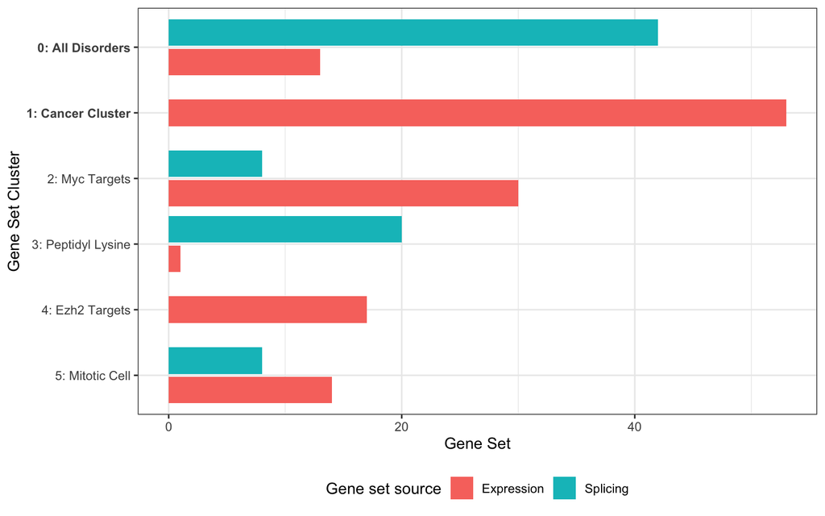

```r
plotBarchart(
  geneSetsList = exampleGsList,
  highlightClusterNo = c(0,1)
)
```

The bar chart shows the cluster sizes and the proportion of each cluster’s gene-sets coming from each source. With multi-source data this immediately highlights clusters dominated by one source versus those shared between sources, which can suggest biology specific to one source (e.g. expression-related cancer cluster) versus shared programs.

Also note that the `highlightClusterNo` argument is available for most plotting functions, making it easy to visually communicate which clusters you think are most interesting.

We can also visualize the gene-set clusters in a UMAP plot:

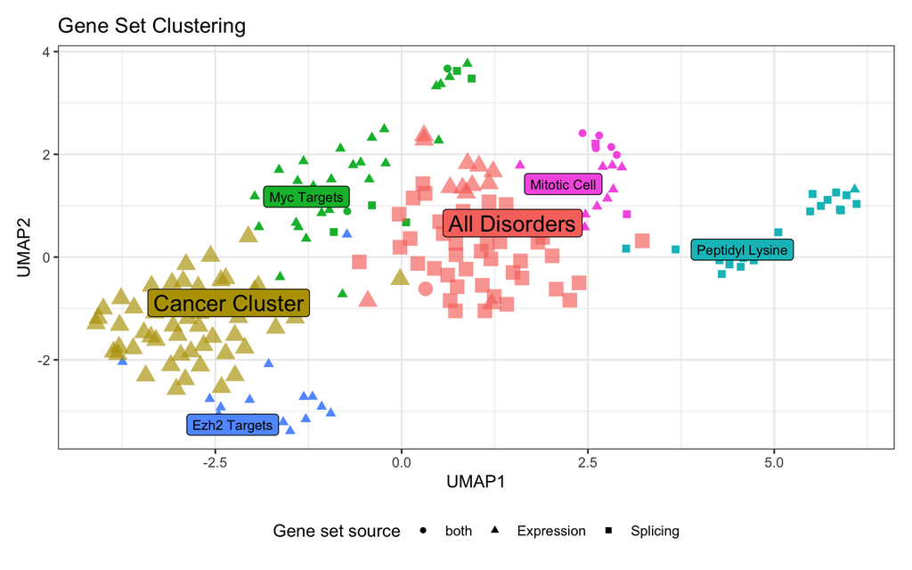

```r
plotUMAP(
  geneSetsList = exampleGsList,
  highlightClusterNo = c(0,1),
  removeClusterId = TRUE,
  pointAlpha = 1 # because there are relatively few gene-sets here
)
```

Which automatically plots the source as the shape. The UMAP plot function has many arguments enabling fine-tuning of the plot. Here we just want to highlight the use of `removeClusterId`. While the cluster numbers are useful for quick referral to clusters (important later), it is often desirable to remove them. Hence the `removeClusterId` argument (implemented in all plot functions) removes the cluster number (e.g. the “1:” prefix in “1: cancer cluster”).

We already mentioned how we see differences in cluster composition. This can naturally also be directly visualized:

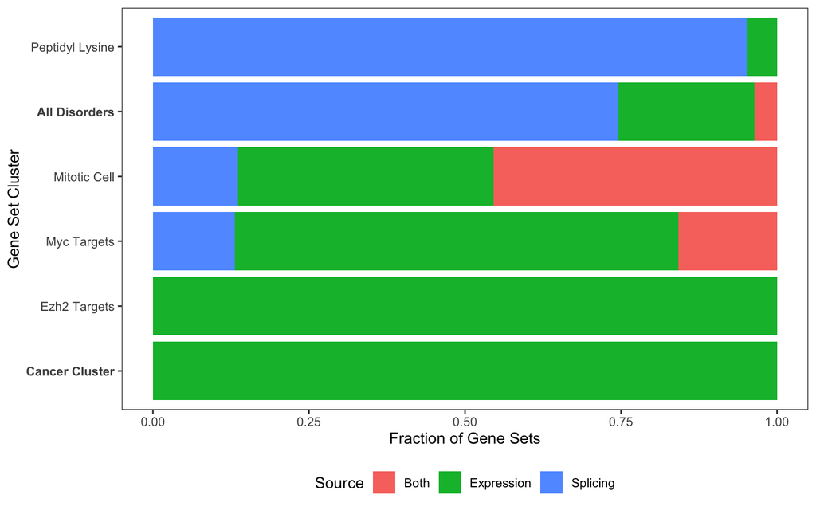

```r
plotProportions(
  geneSetsList = exampleGsList,
  highlightClusterNo = c(0,1),
  removeClusterId = TRUE
)
```

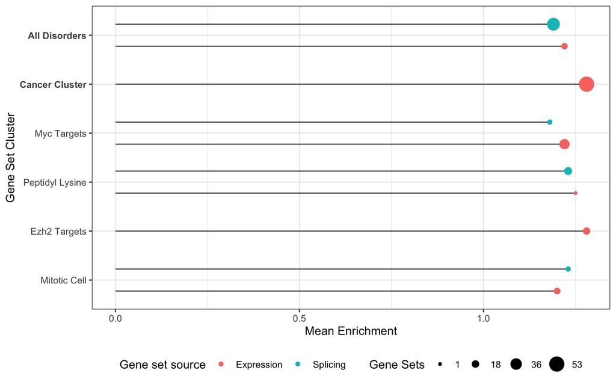

```r
plotEnrichments(
  geneSetsList = exampleGsList,
  highlightClusterNo = c(0,1),
  removeClusterId = TRUE
)
```

But we can also visualize all enrichment scores in a violin plot

```
#> tidyseurat says: This operation lead to duplicated cell names. A data frame is returned for independent data analysis.
```

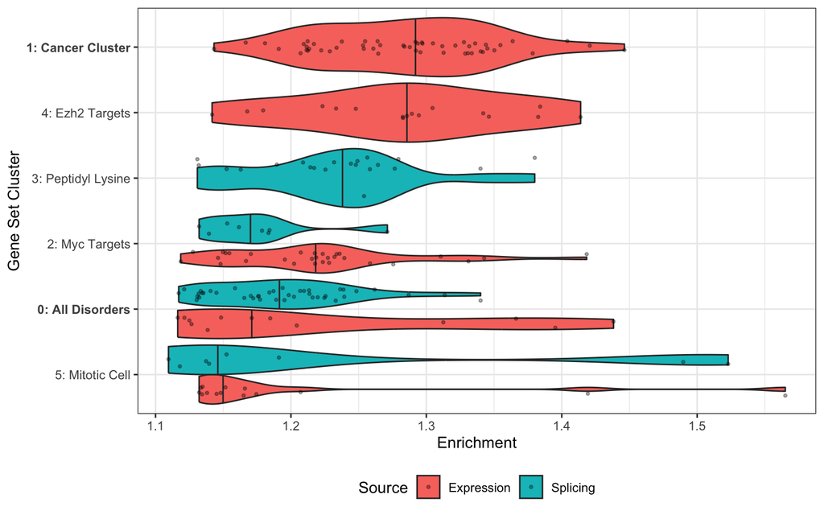

```r
plotViolin(
  geneSetsList = exampleGsList,
  highlightClusterNo = c(0,1),
  removeClusterId = FALSE
)
```

These plots are useful for showing differences in regulation (one cluster being up-regulated while another is down-regulated).

We can investigate how the clusters relate to one another using the per-cluster average dendrogram:

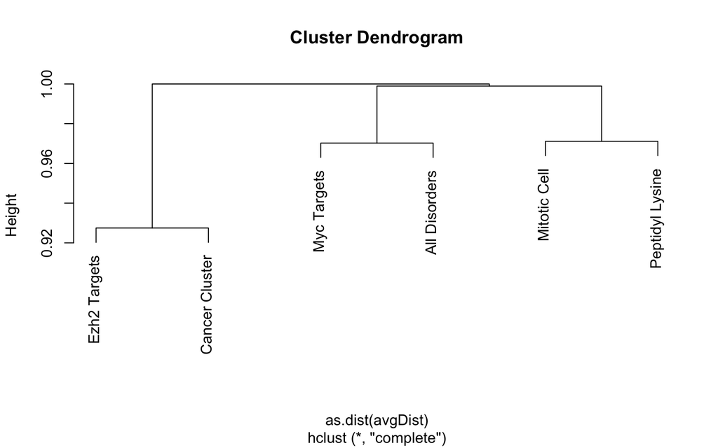

```r
plotDendrogram(
  geneSetsList = exampleGsList,
  removeClusterId = TRUE
)
```

This illustrates the well-known fact that UMAPs can be somewhat misleading about how clusters are positioned relative to each other — the dendrogram and the UMAP can disagree on which clusters are closest.

## Exploring and verifying clusters

The most important thing to get right is the clustering “level” controlled by the `resolution` argument (as shown above in the Cluster and label gene-sets section). `geneSetSimplifyR` picks a sensible default automatically, but we always recommend visualizing how different cluster resolutions affect the clusters via the [clustree R package](https://cran.r-project.org/web/packages/clustree/index.html) here wrapped in the *plotClustree()* function:

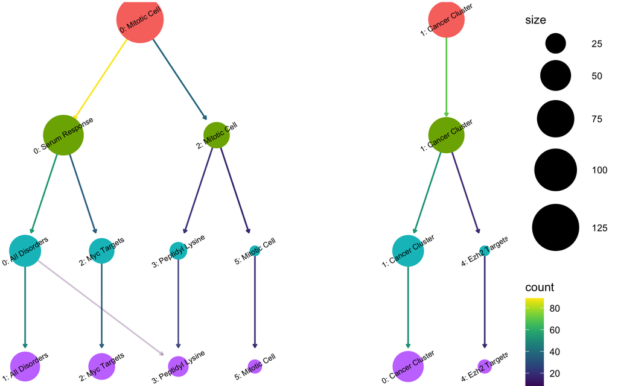

```r
plotClustree(exampleGsList)
```

This is a very powerful way to see how the gene-sets are distributed into different clusters and for helping with verifying the clustering “level”, as determined by the resolution, is correct.

This can naturally be followed up by e.g. a UMAP at a different resolution — here resolution 0.6:

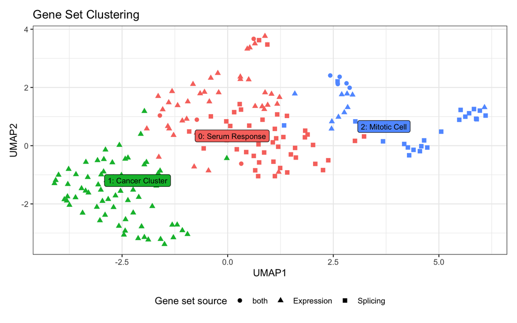

```r
plotUMAP(
  geneSetsList = exampleGsList,
  resolution = 0.6,
  pointAlpha = 1
)
```

Please note the `resolution` parameter is also implemented for all plotting functions.

Let’s try to update the default resolution:

```r
exampleGsList <- updateResolution(
  geneSetsList = exampleGsList,
  resolution = 0.6
)

exampleGsList
```

```
#> [1] "A gsList object with 197 gene sets from 2 source(s) clustered into 3 labeled clusters."
#> Metadata:
#>   algorithm: louvain
#>   k (KNN): 14
#>   LSI elbow cutoff: 28
#>   selected resolution: 0.6
#>   n pathways: 197
```

Once we have verified the cluster resolution is suitable (for your analysis), we can move on to verifying the cluster labels. While we spent a lot of time optimizing the approach `geneSetSimplifyR` uses to extract informative labels for each cluster, it is not a perfect process. Therefore we have built functionality to both explore and change cluster labels.

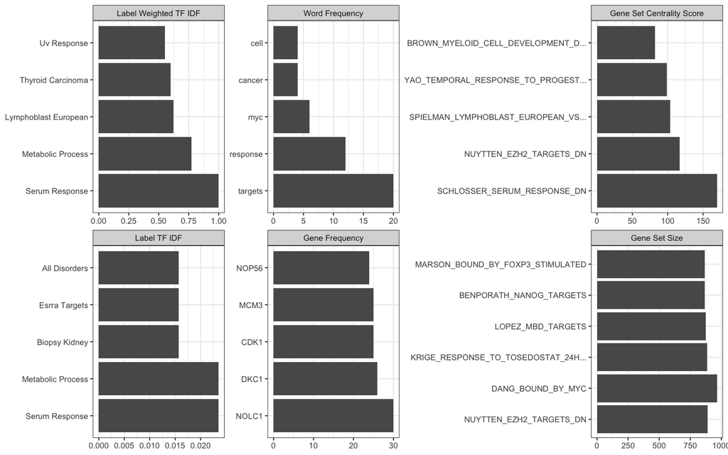

```r
plotClusterLabels(
  geneSetsList = exampleGsList,
  clusterNumber = 0,
  maxChar = 35 # shorten gene-set names to fit in vignette
) +
  theme_bw(base_size = 8) # make font smaller to fit in vignette
```

From which a LOT of summary info can be seen for this particular cluster:

- The label TF-IDF meaning the two-words that are most enriched in this cluster compared to other clusters (bottom left)
- The gene-sets most central in the KNN graph produced (top right)
- The weighted TF IDF - that is the TF IDF scores weighted by gene-set centrality. This is the one that defines the cluster label (top left).
- The most frequent words in the gene-set names (top mid)
- The most frequent genes in the gene-sets (bottom mid)
- The largest gene-sets in the cluster (bottom right)

We recommend that you always inspect the output from *plotClusterLabels()* for ALL your clusters to ensure the labeling is appropriate.

If you think the auto-generated cluster labels could be more precise, you can manually override them. For example, if you determine that cluster 0 is better described as “Serum response downregulation” after checking the [gene-set information](https://www.gsea-msigdb.org/gsea/msigdb/human/geneset/SCHLOSSER_SERUM_RESPONSE_DN.html), the gsList can be updated accordingly:

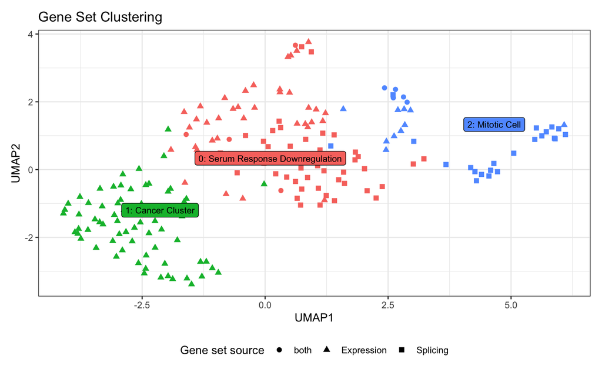

```r
exampleGsList <- updateClusterLabels(
  geneSetsList = exampleGsList,
  clusterNumber = 0,
  newClusterName = 'Serum Response Downregulation'
)

plotUMAP(
  geneSetsList = exampleGsList,
  pointAlpha = 1
)
```

To verify the clustering you can naturally also look at all the gene-sets annotated to a cluster:

```r
gsTable <- extractTable(
  geneSetsList = exampleGsList,
  summarize = FALSE
)

head(gsTable)
```

```
#> # A tibble: 6 × 4
#>   source     pathway                                              enrichment_score cluster
#>   <chr>      <chr>                                                           <dbl> <chr>
#> 1 Expression GRADE_COLON_AND_RECTAL_CANCER_UP                                 1.22 Serum Response Downregulation
#> 2 Splicing   BENPORATH_NANOG_TARGETS                                          1.12 Serum Response Downregulation
#> 3 Expression LEE_BMP2_TARGETS_DN                                              1.22 Serum Response Downregulation
#> 4 Expression RODRIGUES_THYROID_CARCINOMA_POORLY_DIFFERENTIATED_UP             1.23 Serum Response Downregulation
#> 5 Expression CAIRO_HEPATOBLASTOMA_CLASSES_UP                                  1.23 Serum Response Downregulation
#> 6 Expression BERENJENO_TRANSFORMED_BY_RHOA_UP                                 1.21 Serum Response Downregulation
```

We strongly recommend ALWAYS including this table in the supplementary material of an article, as it is essential for both transparency and reproducibility.

For reporting purposes this table can also be summarized:

```r
gsSummary <- extractTable(
  geneSetsList = exampleGsList,
  summarize = TRUE
)

head(gsSummary)
```

```
#> # A tibble: 5 × 5
#>   source     cluster                       `enrichment mean` `enrichment sd` genesets
#>   <chr>      <chr>                                     <dbl>           <dbl>    <int>
#> 1 Expression Serum Response Downregulation              1.22            0.08       43
#> 2 Splicing   Serum Response Downregulation              1.19            0.05       51
#> 3 Expression Cancer Cluster                             1.29            0.07       70
#> 4 Expression Mitotic Cell                               1.2             0.12       15
#> 5 Splicing   Mitotic Cell                               1.24            0.1        27
```

## Plot modifications

All visualization functions return a ggplot2 object:

```r
data("exampleGsList")

p1 <- plotBarchart(
  geneSetsList = exampleGsList,
  highlightClusterNo = c(0,1)
)
class(p1)
```

```
#> [1] "ggplot2::ggplot" "ggplot"          "ggplot2::gg"     "S7_object"       "gg"
```

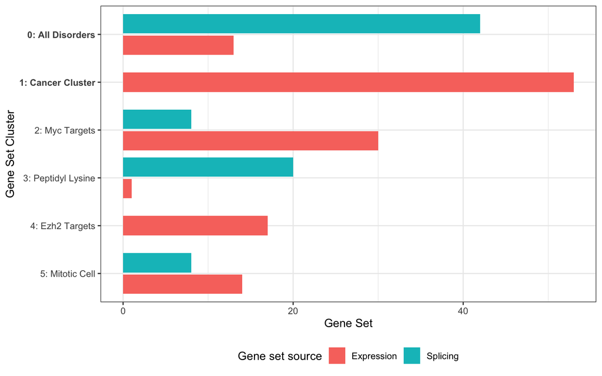

```r
p1
```

This also means all plots can easily be modified using standard ggplot2 operations:

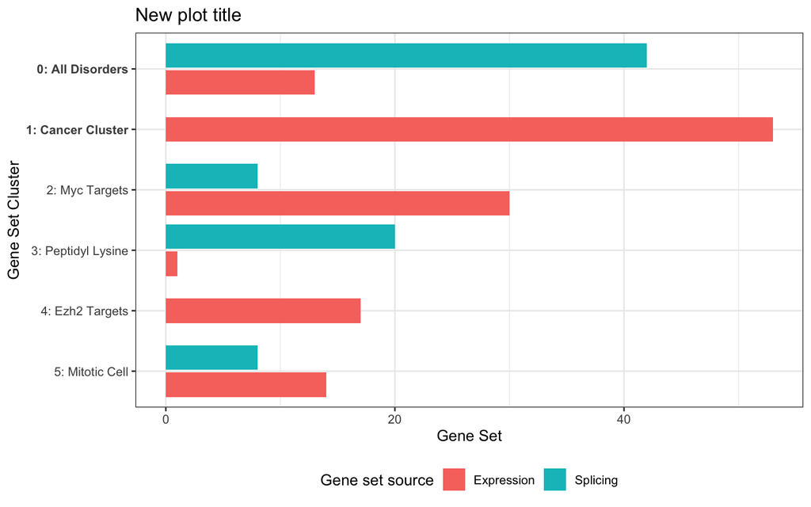

```r
p1 +
  ggtitle('New plot title')
```

Such ggplot2 operations are *really* easy to google since ggplot2 has millions of users. So if you want to modify any plot in some way, just google that in conjunction with ggplot2 and you will find your answer (e.g. “ggplot2 change fill color”).

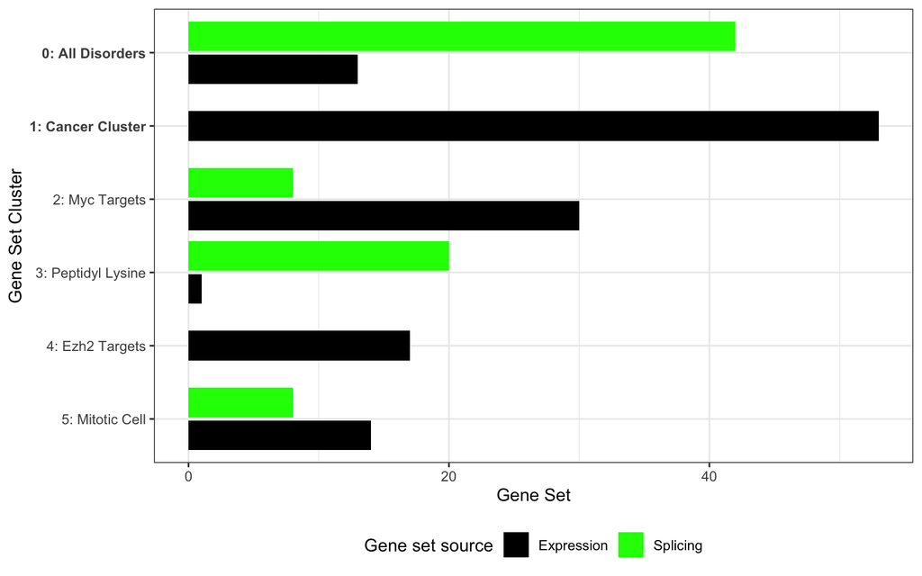

```r
p1 +
  scale_fill_manual(values = c('black','green'))
```

## Convenience parsers for common GSEA tools

`geneSetSimplifyR` ships small helpers that convert the output of popular enrichment-analysis tools into the `geneSetsList` + `geneSetsDF` pair `geneSetSimplifyR()` expects, so you don’t have to reshape the data by hand:

- `parsePairedGSEA()` — parses a `pairedGSEA::paired_ora()` result. Each of the three blocks (`expression`, `splicing`, `paired`) is filtered by its own padj cutoff (`cutoff_exp`, `cutoff_splicing`, `cutoff_paired`) and contributes its surviving pathways as a separate `source`.
- `parseFgsea()` — parses a single `fgsea::fgsea()` result; filters by a `padj` cutoff and labels rows with a user-supplied `source` string. Run it once per analysis (with a distinct `source`) and `rbind()` the resulting `geneSetsDF`s to combine several analyses into one multi-source clustering.
- `getGeneSets()` — fetches MSigDB gene sets (via msigdbr) by collection / sub-collection or by a vector of pathway names. Handy for building a `geneSetsList` from scratch or for inspecting the members of specific pathways after clustering.

Each function returns a list with two elements, `geneSetsList` and `geneSetsDF`, ready to pass straight into `geneSetSimplifyR()`:

```r
# pairedGSEA example
parsed <- parsePairedGSEA(
  oraResult       = oraResult, # output from pairedGSEA::paired_ora()
  geneSets        = mSigDB, # mSigDB gene sets
  cutoff_exp      = 0.05,
  cutoff_splicing = 0.05,
  cutoff_paired   = 0.05
)
gss <- geneSetSimplifyR(
  geneSetsList = parsed$geneSetsList,
  geneSetsDF   = parsed$geneSetsDF
)

# fgsea example is shown in the next section.
```

See `?parsePairedGSEA`, `?parseFgsea`, and `?getGeneSets` for the full argument list.

# How to do gene-set enrichment analysis/overrepresentation analysis

Let’s look at how to produce the input for `geneSetSimplifyR` via the `fgsea` package and its example data:

```r
library(fgsea)

data(examplePathways)
data(exampleRanks)
```

And here are the genes of interest (e.g. significant genes) from the `fgsea` package:

```r
sigGenes <- tail(names(exampleRanks), 750)
head(sigGenes)
```

```
#> [1] "105352" "18476"  "380912" "20788"  "57875"  "56175"
```

Then, we can run a simple over-representation analysis (ORA) or gene set enrichment analysis (GSEA) using the `fgsea` package as follows:

```r
# ORA example
oraRes <- fora(
  pathways = examplePathways,
  genes    = sigGenes,
  universe = names(exampleRanks)
)
head(oraRes[order(padj), ])
```

```
#>                                            pathway         pval         padj foldEnrichment overlap  size
#>                                             <char>        <num>        <num>          <num>   <int> <int>
#> 1:                              5990980_Cell_Cycle 2.692788e-26 3.823760e-23       3.642276      84   369
#> 2:                     5990979_Cell_Cycle,_Mitotic 2.327765e-25 1.652713e-22       3.835962      76   317
#> 3:                    5991851_Mitotic_Prometaphase 3.588483e-21 1.698549e-18       6.829268      35    82
#> 4: 5992217_Resolution_of_Sister_Chromatid_Cohesion 1.316533e-18 4.673693e-16       6.702703      31    74
#> 5:                                 5991454_M_Phase 1.103607e-14 3.134243e-12       3.884393      42   173
#> 6:            5991757_RHO_GTPases_Activate_Formins 6.216227e-14 1.471174e-11       5.538462      27    78
#>    overlapGenes
#>          <list>
#> 1: 11799, 1....
#> 2: 11799, 1....
#> 3: 11799, 1....
#> 4: 11799, 1....
#> 5: 11799, 1....
#> 6: 11799, 1....
```

```r
# fgsea example
fgseaRes <- fgsea(pathways = examplePathways,
                  stats    = exampleRanks)
head(fgseaRes[order(padj), ])
```

```
#>                                            pathway         pval         padj   log2err        ES      NES  size
#>                                             <char>        <num>        <num>     <num>     <num>    <num> <int>
#> 1:                              5990980_Cell_Cycle 1.193611e-26 1.694928e-23 1.3422338 0.5388497 2.686780   369
#> 2:                     5990979_Cell_Cycle,_Mitotic 1.307714e-25 9.284769e-23 1.3110148 0.5594755 2.765127   317
#> 3:                    5991851_Mitotic_Prometaphase 2.690874e-18 1.273681e-15 1.1053366 0.7253270 2.966706    82
#> 4: 5992217_Resolution_of_Sister_Chromatid_Cohesion 2.855582e-17 1.013732e-14 1.0672100 0.7347987 2.966482    74
#> 5:                                 5991454_M_Phase 1.406369e-14 3.994087e-12 0.9865463 0.5576247 2.551713   173
#> 6:                              5991024_Metabolism 2.420129e-14 5.727639e-12 0.9759947 0.3589482 1.898202   896
#>     leadingEdge
#>          <list>
#> 1: 66336, 6....
#> 2: 66336, 6....
#> 3: 66336, 6....
#> 4: 66336, 6....
#> 5: 66336, 6....
#> 6: 11676, 2....
```

**Both ORA and GSEA results from fgsea can be used as input to our package in the same way.** Below, we use the ORA results to demonstrate this workflow.

```r
parsed <- parseFgsea(oraRes, examplePathways, cutoff=0.05)

exampleGsList <- geneSetSimplifyR(
  geneSetsList = parsed$geneSetsList,
  geneSetsDF   = parsed$geneSetsDF,
  verbose      = FALSE,
  removeFirstWord = TRUE
)
exampleGsList
```